[← Página principal](https://valentinzarate.github.io/Curso_JAM_EM/index.html)

# Números Complejos

# Posiciones en un plano

En ecología de movimientos (EM), al igual que en otros análisis con datos espaciales, cada observación contiene información sobre la posición de un individuo en el espacio y sobre el momento en que esa posición fue registrada.

El componente espacial está generalmente definido por dos coordenadas en un plano, por ejemplo *x* e *y*, mientras que el componente temporal está representado por un tiempo *t*. De esta manera, una observación puede representarse de forma simple como:

**(x<sub>i</sub>, y<sub>i</sub>, t<sub>i</sub>)**

En términos conceptuales, podemos pensar entonces que cada observación tiene dos componentes:

**Observación = Espacio + Tiempo**

Las coordenadas *x* e *y* indican **dónde** se encontraba el individuo, mientras que *t* indica **cuándo** ocupó esa posición.

Una única observación describe una posición en un momento determinado, pero no describe movimiento. Para caracterizar un desplazamiento necesitamos al menos dos observaciones consecutivas:

**(x<sub>1</sub>, y<sub>1</sub>, t<sub>1</sub>) → (x<sub>2</sub>, y<sub>2</sub>, t<sub>2</sub>)**

## Secuencia de localizaciones

Como podemos intuir, una trayectoria puede entenderse como un conjunto de localizaciones que ocurren sucesivamente en el tiempo. Esta estructura de datos constituye la base de la ecología de movimientos. Para ser prácticos, primero vamos a concentrarnos en el componente espacial de las observaciones y luego incorporaremos su estructura temporal en el [tema 2](https://valentinzarate.github.io/Curso_JAM_EM/tema_2/tema2.html).

### Números complejos

Para comprender y manejar el componente espacial de una base de datos de EM podemos trabajar con el conjunto de los números complejos $\mathbb{C}$. Los números complejos no son una estructura extraña o inmanejable, sino una extensión del sistema numérico que nos permite representar y operar con dos dimensiones de manera algebraicamente sencilla.

Un número complejo está formado por dos números reales y puede escribirse como:

$z = x + yi$

donde $x$ e $y$ pertenecen a los números reales $\mathbb{R}$, mientras que $i$ es la unidad imaginaria, definida por la propiedad $i^2 = -1$. De esta manera, un número complejo puede asociarse directamente con un punto $(x,y)$ en el plano $\mathbb{R}^2$.

El punto $(x,y)$ puede, por supuesto, representarse simplemente mediante dos números reales. La ventaja de escribirlo como un único número complejo $z = x + yi$ aparece cuando queremos operar con posiciones y desplazamientos. La estructura algebraica de los números complejos permite realizar con operaciones simples cálculos que involucran simultáneamente ambas coordenadas.

En particular, la presencia de $i$ incorpora naturalmente la estructura ortogonal del plano y permite representar rotaciones mediante multiplicaciones. Esto hace que operaciones relacionadas con desplazamientos, distancias, direcciones y ángulos puedan expresarse de forma compacta utilizando las reglas algebraicas de los números complejos.

# Número complejo y R

Yendo rápidamente a lo aplicado, R tiene herramientas base diseñadas para trabajar fácilmente con números complejos. Estas funciones nos permiten entender, desde una perspectiva algebraica, muchas de las operaciones que luego utilizamos para describir el movimiento. Por esto, es importante, tanto conceptual como analíticamente, entender cómo obtener medidas e interpretarlas a partir de un par ordenado de coordenadas.

Veamos entonces algunas operaciones básicas. Comencemos representando una “localización” en un plano en R:

```r
x <- 1
y <- 2
```

Por ahora tenemos dos números reales separados, sin ninguna relación espacial explícita entre ellos. Sin embargo, podemos meterlos en un plano (dos ejes cartesianos) y representar su intersección como un punto con una ubicación específica

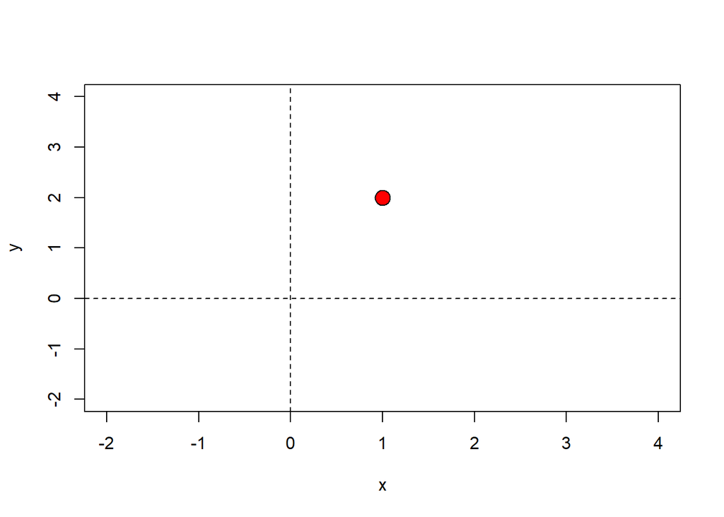

```r
plot(x,y, type = "o", xlim = c(-2,4), ylim = c(-2,4), pch = 21, bg = "red", cex = 2)
abline(v=0,h=0,lty =2)
```

Nada raro, simplemente un punto en un plano…

Sin embargo, hacer cálculos directamente sobre un elemento como $(x,y)$ puede resultar poco intuitivo. Vamos a usar números complejos para poder trabajar de manera más directa con este par ordenado. Para eso, primero vamos a reescribir este mismo punto pero usando $i$, la unidad imaginaria que mencionamos antes y que nos permite “unificar” este par de números reales en un solo número. Aunque al principio tener una $i$ al medio puede parecer molesto, vamos a ver que simplifica gran parte del álgebra. La gran mayoría de las operaciones que realizan las librerías de R para ecología de movimientos parten de esta misma lógica algebraica. Por eso, vamos a partir de los números complejos para entender cómo trabajar con posiciones, desplazamientos y trayectorias.

```r
z <- x + 1i * y

z
```

```
## [1] 1+2i
```

Ahora tenemos ese númerito $z$, con ese aspecto raro de `1+2i`.

Vemos que R lo puede reconocer como lo que es, “complex”. Además, podemos reconocer su parte real y su parte imaginaria.

```r
class(z)
```

```
## [1] "complex"
```

```r
Re(z)
```

```
## [1] 1
```

```r
Im(z)
```

```
## [1] 2
```

Vamos a volver a ver este punto, pero ahora agregando algo que nos va a servir para lo que sigue. Si pensamos la posición $(x,y)$ como un vector que parte desde el origen hasta nuestro punto, ese vector queda caracterizado por dos propiedades fundamentales: una **magnitud** (o módulo) y una **dirección** (o argumento).

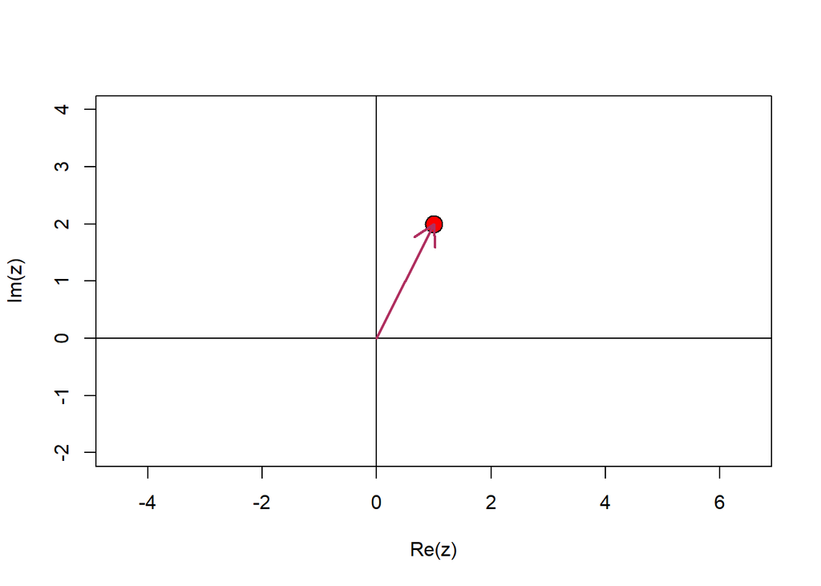

```r
plot(z, type = "o", xlim = c(-2,4), ylim = c(-2,4), pch = 21, bg = "red", cex = 2, asp = 1)
abline(h=0,v=0)
arrows(0,0,Re(z), Im(z), length = 0.2, col = "maroon", lwd = 2)
```

Para que no nos asustemos, vemos que R puede lidiar sin mucho lío con estos números complejos. Podemos hacer simples operaciones y plotearlas.

Una simple operación sería multiplicar este $z$ por $i$, es decir un complejo con 0 en su parte real y 1 en su imaginario.

```r
z_r <- z * 1i
```

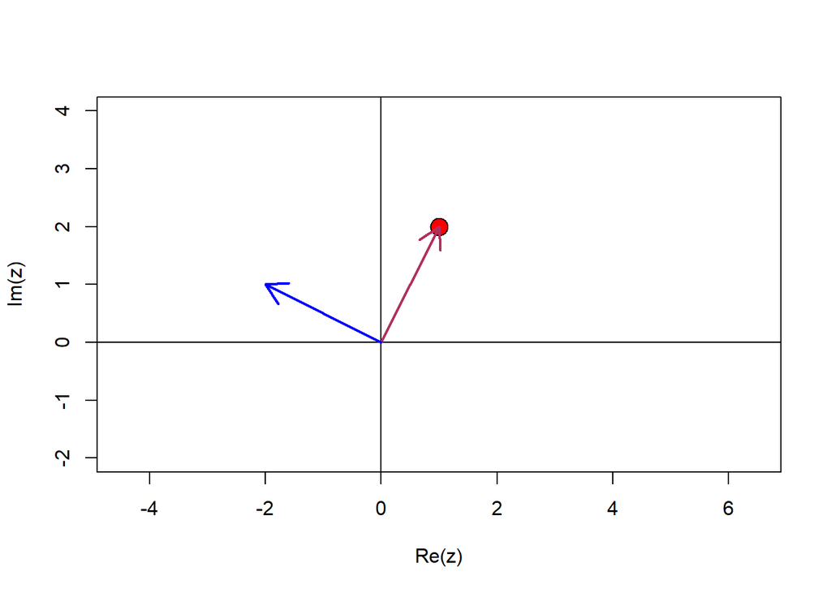

```r
plot(z, type = "o", xlim = c(-2,4), ylim = c(-2,4), pch = 21, bg = "red", cex = 2, asp = 1)
abline(h=0,v=0)
arrows(0,0,Re(z), Im(z), length = 0.2, col = "maroon", lwd = 2)
arrows(0,0,Re(z_r), Im(z_r), length = 0.2, col = "blue", lwd = 2)
```

Vemos que esto genera un cambio en la dirección. Podríamos sumarle otro número complejo para desplazar el vector y varias cosas más.

### Trayectoria simple

Vamos a extender esto a varios puntos para no detenernos demasiado.

Genero dos conjuntos de números reales y los gráfico.

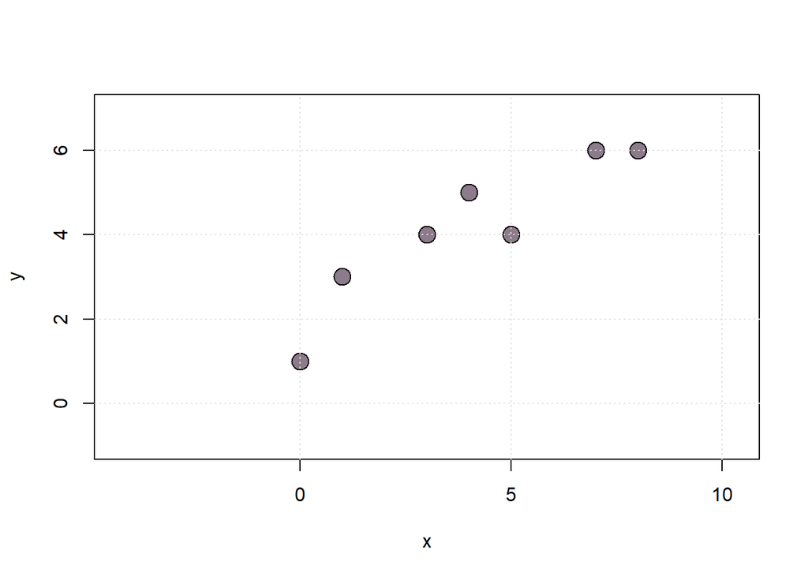

```r
x <- c(0,1,3,4,5,7,8)
y <- c(1,3,4,5,4,6,6)

plot(x,y, asp =1, pch = 21, xlim =c(-1,7), ylim = c(-1,7), bg = "thistle4", cex = 2)
grid(col = "grey88")
```

Estos dos conjuntos de números reales representan las coordenadas (latitud y longitud, Easting y Northing, lo que sea según el sistema de referencia).

Hacemos la secuencia de números complejos, de la misma forma que antes

Para visualizar los desplazamientos entre localizaciones consecutivas vamos a usar la función `arrows()` de R base. Esta función necesita cuatro valores para cada flecha: la coordenada *x* inicial, la coordenada *y* inicial, la coordenada *x* final y la coordenada *y* final.

Como queremos unir cada localización con la siguiente, necesitamos formar dos secuencias desplazadas. `z[-length(z)]` contiene todas las localizaciones excepto la última y representa los puntos de partida, mientras que `z[-1]` contiene todas las localizaciones excepto la primera y representa los puntos de llegada.

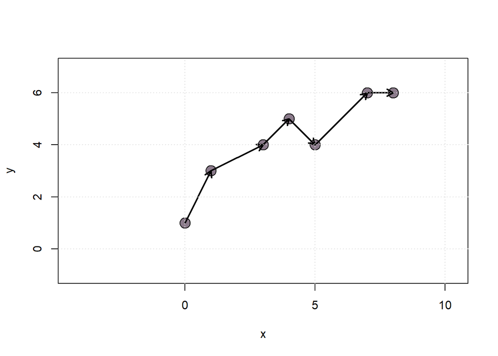

```r
z <- x + 1i * y

plot(x,y, asp =1, pch = 21, xlim =c(-1,7), ylim = c(-1,7), bg = "thistle4", cex = 2)
arrows(Re(z[-length(z)]), Im(z[-length(z)]), Re(z[-1]), Im(z[-1]), length = .1, col = "black", lwd = 2)
grid(col = "grey88")
```

# Vectores

Estas flechitas ya empiezan a parecerse a la trayectoria de un bicho, con magnitud y dirección. Entonces podemos ver cada flechita como un vector. En ecología de movimentos estos vectores que conectan dos posiciones consecutivas son conocidos como **pasos** (*steps*). De estos pasos nos interesan dos cosas: el largo y el ángulo (de giro respecto al plano y respecto a otros pasos).

## Largo de pasos

Estos pasos no son más que desplazamientos en dos ejes. Pero recordemos que, al trabajar con números complejos, ambos ejes están integrados en un único número $z$.

```r
z
```

```
## [1] 0+1i 1+3i 3+4i 4+5i 5+4i 7+6i 8+6i
```

Si vemos en detalle los primeros dos puntoes vemos que tenemos $z1 = 0 + 1i$ y $z2 = 1 + 3i$. Podemos leer esto de otra forma: para moverme de $z1$ a $z2$ tengo que desplazarme una posición en el eje “real” o eje $x$ y dos posiciones en el eje “imaginario o eje $y$.

```r
z[2] - z[1]
```

```
## [1] 1+2i
```

Este nuevo número complejo es el paso que tengo que dar para ir de $z[1]$ a $z[2]$. Entonces:

```r
steps <- diff(z)
steps
```

```
## [1] 1+2i 2+1i 1+1i 1-1i 2+2i 1+0i
```

Bien, tenemos todas las “indicaciones” de cómo ir de una posición a la que sigue. Aunque incomode inicialmente, los números complejos tienen propiedades algebráicas muy directas para operar en un espacio ortogonal. A su vez, estas operaciones nos devuelven rápido al mundo de los reales.

Sin entrar en detalles trigonométricos y la ecuación de Euler, con simples operaciones podemos obtener lo que nos interesa, el largo y el ángulo de este cambio de localizaciones.

Lo veamos con un único paso para que se entienda mejor

```r
paso1 <- z[2] - z[1]
paso1
```

```
## [1] 1+2i
```

```r
largo_paso <- Mod(paso1)
largo_paso
```

```
## [1] 2.236068
```

$$z_2-z_1=1+2i$$

Geométricamente:

$$\Delta x=1,\qquad \Delta y=2$$

por lo que, si recuerdan pitagoras:

$$|z_2-z_1|=\sqrt{1^2+2^2}=\sqrt{5}$$

Algebraicamente, el módulo es un número por su conjugado:

$$(1+2i)(1-2i)=1+4=5$$

y entonces:

$$|1+2i|=\sqrt{5}=2.236$$

Con esto tenemos la unidad de magnitud básica, el largo del paso. En ecología de movimientos sería la distancia que recorrió el bicho entre un punto y el siguiente. Tenemos un valor, dentro de los números reales, que nos dice cómo fue de un punto a otro, comunmente en metros.

## La dirección

Además de necesitar saber cuánto se movió, es clave entender hacia dónde se movió. Para esto necesiamos calcular los ángulos de giro. A quien quiera profundizar puede entrar a este [LINK](https://valentinzarate.github.io/taller_mov/tema_1/num_com.html#_12_Rotaci%C3%B3n_y_la_f%C3%B3rmula_de_Euler_) y ver detalles sobre la rotación de vectores y la fórmula de Euler (desde seccion 1.2).

Acá nos vamos a limitar a calular el **Argumento** del vector (paso) de interes. El argumento de un vector representa el ángulo del mismo respecto al eje horizontal del plano.

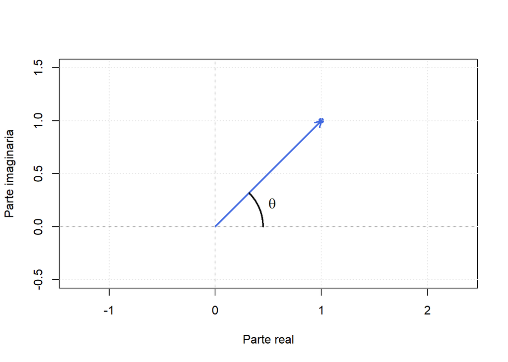

Muy lindo, pero el eje X es algo irreal y no tiene mucho sentido en térmios de movimiento ni ecología. Lo que si puede interesarnos es cuánto giro el bicho en relación a la dirección anterior. Es decir

```r
paso1 <- z[3] - z[2]
paso2 <- z[4] - z[3]

giro <- Arg(paso2) - Arg(paso1)
```

```r
giro
```

```
## [1] 0.3217506
```

Es un numero en radianes

```r
giro * 180 / pi
```

```
## [1] 18.43495
```

Son unos 18 grados de giro

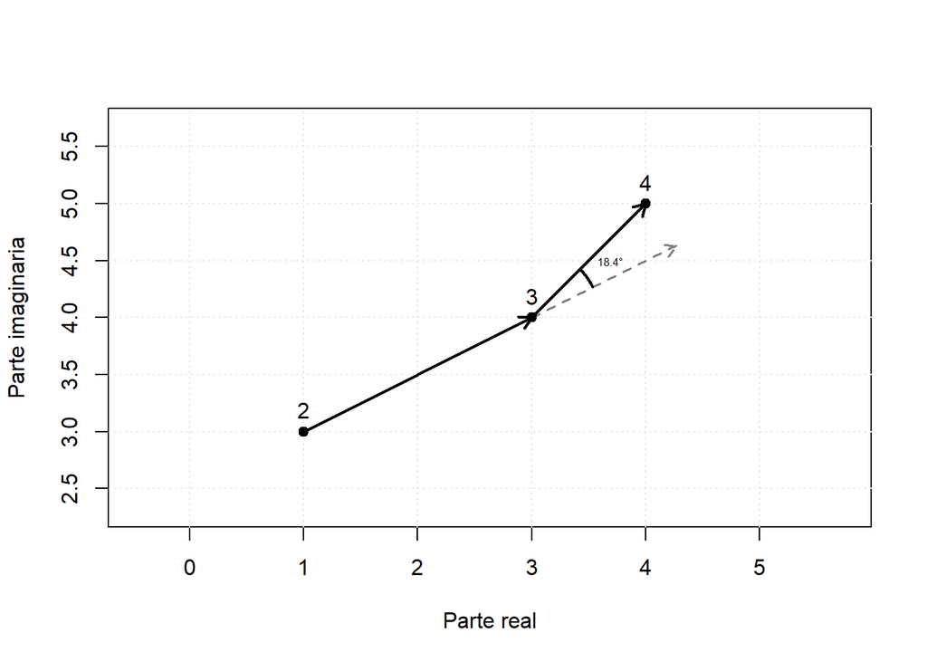

## Métricas básicas

Vamos ahora a calcular estas dos métricas básicas (largo de paso y ángulos de giro) para nuestro $Z$. Las 4 operaciones que están en el chunk de abajo son el primer cálculo para conectar un grupo de puntos GPS con un análisis de movimientos, sin estas métricas dificilmente podamos analizar una trayectoria.

```r
pasos <- diff(z)
largo_pasos <- Mod(pasos)
argumento <- Arg(pasos)
giro <- diff(argumento)
```

Acá tenemos una secuencia de numeros reales, que comunmente van a ser metros.

```r
largo_pasos
```

```
## [1] 2.236068 2.236068 1.414214 1.414214 2.828427 1.000000
```

```r
giro
```

```
## [1] -0.6435011  0.3217506 -1.5707963  1.5707963 -0.7853982
```

Acá tenemos una secuencia de angulos de giro en radianes. En general se deja en ese sistema, pero para interpretación a veces facilita pasar a grados (giro *180 / pi)

# Trayectoria simulada

Vamos un paso más allá para generar una secuencia de localizaciones más parecida a una trayectoria. Cuando la resolución temporal de los *fixes* es suficientemente alta, las trayectorias suelen presentar una fuerte autocorrelación espacial: la posición en $z_i$ tiende a estar espacialmente relacionada con la posición anterior $z_{i-1}$.

En R base podemos combinar dos funciones simples para generar una trayectoria con este tipo de estructura: `arima.sim()` y `cumsum()`.

No vamos a entrar en detalle en estos modelos. Para nuestro objetivo, alcanza con saber que `arima.sim()` genera una serie de valores autocorrelacionados. En este caso usamos un modelo autorregresivo con `ar = 0.9`, de modo que cada valor depende fuertemente del valor anterior.

Luego, `cumsum()` calcula la suma acumulada de esos valores. Es decir, interpreta cada nuevo valor como un cambio o desplazamiento y lo agrega a la posición anterior. De esta forma obtenemos una secuencia de posiciones sucesivas en cada eje.

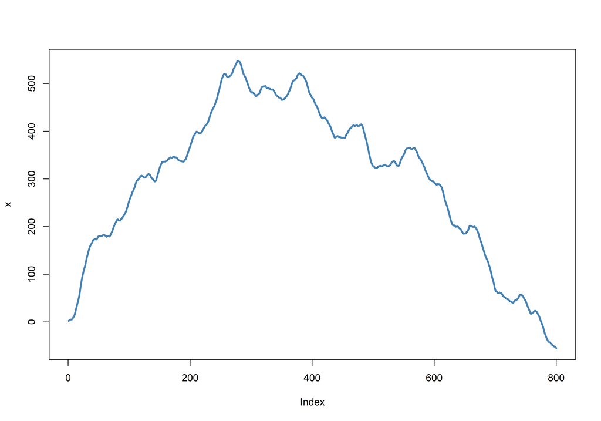

```r
x <- cumsum(arima.sim(n = 800, model = list(ar = 0.9)))
y <- cumsum(arima.sim(n = 800, model = list(ar = 0.9)))


plot(x, type = "l", col = "steelblue", lwd = 3)
```

Hacemos $z$ y lo ploteamos como antes.

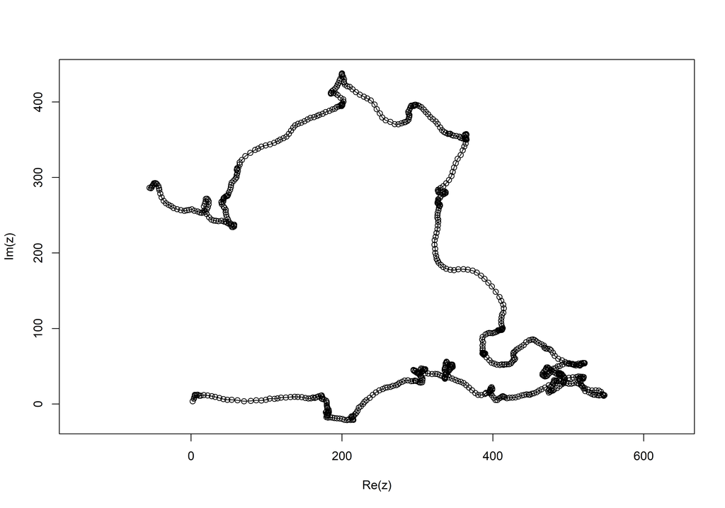

```r
z <- x + 1i * y

plot(Re(z), Im(z), type = "o", asp = 1)
```

Ahora tiene más sentido ver largo de pasos y giros

```r
pasos <- diff(z)
largo <- Mod(pasos)
giro <- diff(Arg(pasos))
```

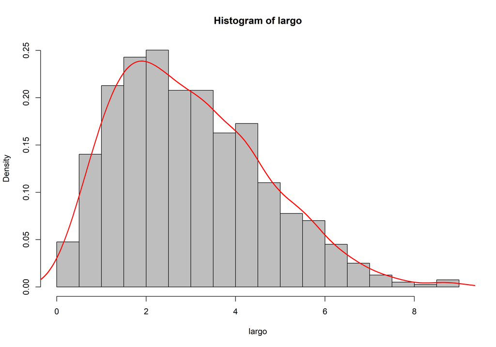

```r
hist(largo, col = "grey", breaks= 20,freq = FALSE)
lines(density(largo), col = "red", lwd = 2)
```

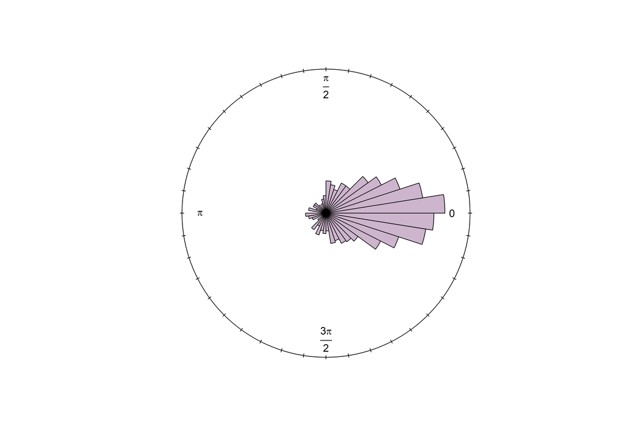

```r
giro <- circular::as.circular(giro)

circular::rose.diag(giro,
                    bins = 40,
                    col = "thistle3",
                    prop = 2)
```

Para que esto vaya tomando sentido lo convertimos en ‘data.frame’. Le vamos a unir las coordenadas, el número complejo, los pasos, el largo de estos pasos y sus ángulos de giro. Los `NA` son necesarios para rellenar las filas que lógicamente van a quedar vacías. Por ejemplo, la primera posición no puede tener un paso ya que no tiene un punto antes que ella, así que quedará como NA. Para ángulos de giro necesitamos 3 posiciones, por lo que última también quedará vacía.

```r
df <- data.frame(z,x,y)

df$step <- c(NA, pasos)
df$sl <- c(NA, largo)
df$ta <- c(NA, giro, NA)

head(df, 10)
```

|  | z | x | y | step | sl | ta |
| --- | --- | --- | --- | --- | --- | --- |
| 1 | 2.094939+ 3.715368i | 2.094939 | 3.715368 | NA | NA | NA |
| 2 | 3.647668+ 7.070284i | 3.647668 | 7.070284 | 1.55272909+3.35491605i | 3.6968134 | 0.11341218 |
| 3 | 4.216416+ 8.786231i | 4.216416 | 8.786231 | 0.56874794+1.71594664i | 1.8077464 | 0.05981414 |
| 4 | 4.786921+10.928750i | 4.786921 | 10.928750 | 0.57050491+2.14251945i | 2.2171751 | 0.19070626 |
| 5 | 4.877987+12.236330i | 4.877987 | 12.236330 | 0.09106659+1.30758024i | 1.3107476 | -2.34942947 |
| 6 | 5.225353+11.842372i | 5.225353 | 11.842372 | 0.34736590-0.39395842i | 0.5252298 | 1.03849908 |
| 7 | 7.121448+12.207683i | 7.121448 | 12.207683 | 1.89609477+0.36531159i | 1.9309655 | -0.09441788 |
| 8 | 8.724663+12.361929i | 8.724663 | 12.361929 | 1.60321527+0.15424601i | 1.6106182 | -0.67058953 |
| 9 | 10.628151+11.129263i | 10.628151 | 11.129263 | 1.90348757-1.23266647i | 2.2677592 | 0.53045354 |
| 10 | 12.617578+11.041231i | 12.617578 | 11.041231 | 1.98942723-0.08803143i | 1.9913740 | 0.23937892 |

## Segmentación

Calculamos los puntos de corte y clasificamos cada paso:

```r
cuts <- quantile(df$sl, probs = c(0, 1.5/3, 2/3, 1), na.rm = TRUE)

df$sl_class <- cut(
  df$sl,
  breaks = cuts,
  include.lowest = TRUE,
  labels = c("cortos", "intermedios", "largos"))
```

Ahora vamos a plotear esta clasificación sobre la trayectoria. Primero hacemos un gráfico vacío con `plot(type=“n”)` y luego dibujamos cada paso individualmente usando `segments()`.

Para hacerlo recorremos la trayectoria con un *loop*. En cada iteración, `segments()` conecta la localización anterior con la actual, mientras que el color de ese segmento se asigna según la categoría que guardamos antes en `sl_class`. Entonces, los pasos cortos, intermedios y largos quedan coloreaditos a lo largo de toda la trayectoria.

Finalmente, agregamos dos puntos para identificar el inicio y el final de la trayectoria.

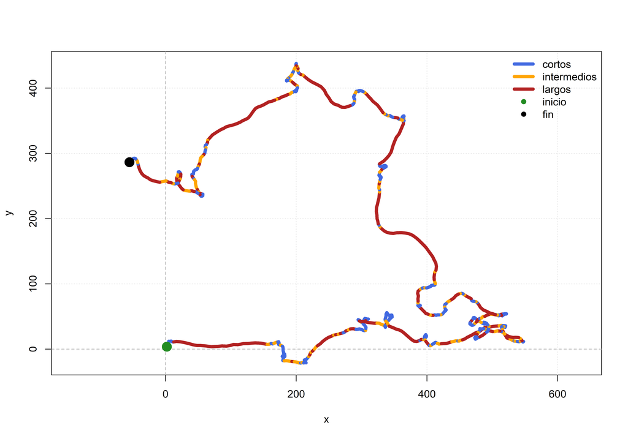

```r
cols <- c("cortos" = "royalblue", "intermedios" = "orange", "largos" = "firebrick")

plot(df$x, df$y,
     type = "n",
     asp = 1,
     xlab = "x",
     ylab = "y")

grid(col = "gray90")
abline(h = 0, v = 0, col = "gray70", lty = 2)

for(i in 2:nrow(df)) {
  segments(df$x[i - 1], df$y[i - 1],
           df$x[i], df$y[i],
           col = cols[as.character(df$sl_class[i])],
           lwd = 5)
}


points(df$x[1], df$y[1], pch = 19, col = "forestgreen", cex = 2)
points(df$x[nrow(df)], df$y[nrow(df)], pch = 19, col = "black", cex = 2)

legend("topright",
       legend = c("cortos", "intermedios", "largos", "inicio", "fin"),
       col = c("royalblue", "orange", "firebrick", "forestgreen", "black"),
       lwd = c(5, 5, 5, NA, NA),
       pch = c(NA, NA, NA, 19, 19),
       bty = "n")
```